# DATA Assessment 2024-25

From the previous 2NF definition provided, the table is not in 2NF as there are several partial dependencies. The following 3 tables are in 2NF:

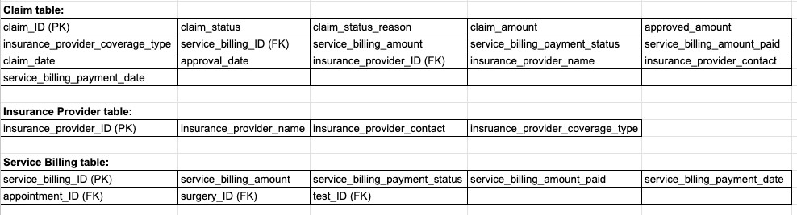

**3NF:**

In the 2NF tables, there exists transitive dependencies in the claim table, which means that the table is not in 3NF: Claim table:

claim _ID -> insurance_provider_ID -> insurance_provider_name, insurance_provider_contact, insurance_provider_coverage_type claim_ID -> service_billing_ID -> service_billing_amount, service_billing_payment_status, service_billing_amount_paid, service_billing_payment_date

Appointment_ID, surgery_ID and test_ID should also be separated into different corresponding tables so that they could be added into the system without the need to have a service bill.

The following tables are now in 3NF:

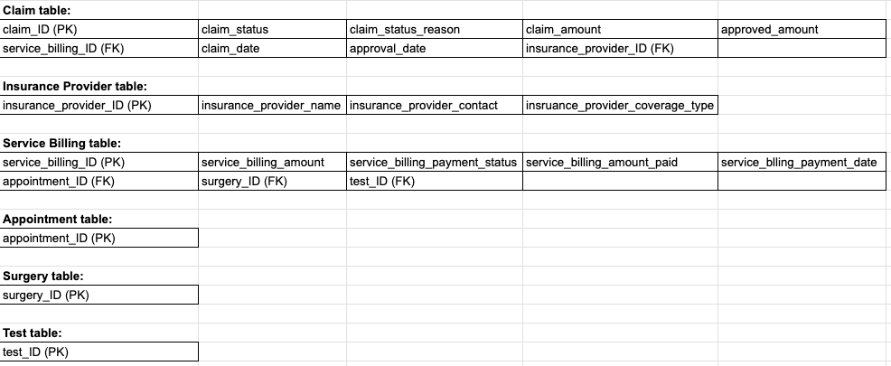

In the service billing table, each row should have 2 of the appointment_ID/surgery_Id/test_ID to be null, assuming that 1 service bill corresponds to 1 appointment, surgery or test (not all 2 or 3 at once).

**4)Normalising Medical_Appointments_Data table**

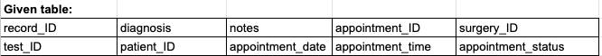

primary_key: Composite keys = {record_ID, appointment_ID, surgery_ID, test_ID, patient_ID}

**1NF:** The table is already in 1NF

**2NF:**

Functional dependencies:

- FD1: record ID -> (functionally determines) -> diagnosis, notes, patient_ID, surgery_ID, test_ID, appointment_ID
- FD2: appointment_ID -> (functionally determines) -> appointment_date, appointment_time, appointment_status, patient_ID

From FD1 and 2, there are non primary key attributes dependent on a proper subset of the primary key (partial dependecy). So, the table is not in 2NF.

The following are in 2NF:

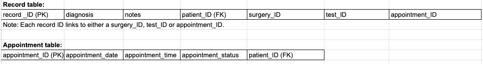

**3NF:**

There are no non-primary key attributes that are transitively dependent on the primary key, so the tables are in 3NF. We should however separate the surgery_ID, test_ID and patient_ID into corresponding tables.

The following 5 tables are in 3NF:

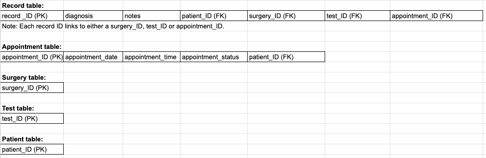

**5) Normalising Medical_Surgeries_Data table**

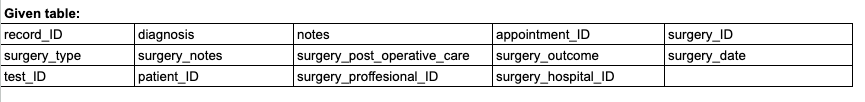

**1NF:** The table is already in 1NF.

**2NF:**

Functional dependencies:

- FD1: record_ID -> (functionally determines) -> diagnosis, notes, patient_ID, appointment_ID, surgery_ID, test_ID, surgery_professional_ID
- FD2: appointment_ID -> (functionally determines) -> patient_ID
- FD3: surgery_ID -> (functionally determines) -> surgery_professional_ID, surgery_hospital_ID, surgery_date, surgery_type, surgery_notes, surgery_post_operative_care, surgery_outcome, patient_ID

From FD 1 - 3, there are several non primary key attributes dependent on a proper subset of the primary key (partial dependecy). So, the table is not in 2NF.

The corresponding 2NFs consists of the following tables:

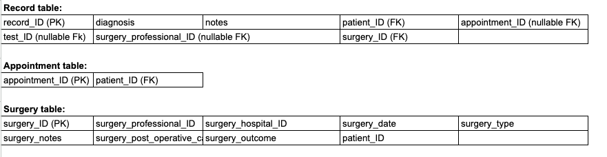

In the record table, record_ID links to a single appointment_ID, test_ID or surgery_ID, so 1 of these 3 will have a value while the other 2 can be null. If and only if surgery_ID is non null, then surgery_professional_ID must also be non null.

**3NF:**

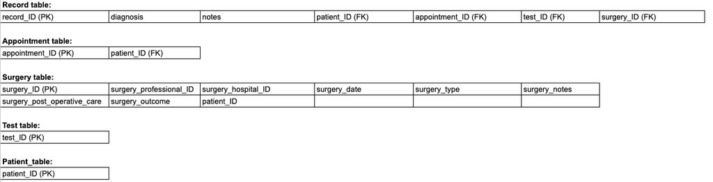

**6) Normalising Medical_tests_data table**

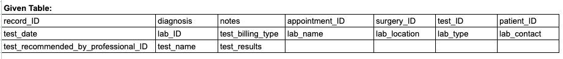

Primary key: Composite keys = {record_ID, appointment_ID, surgery_ID, test_ID, patient_ID, test_recommended_by_professional_ID, lab_ID}

**1NF:** The table is already in 1NF.

**2NF:** Functional dependencies:

- FD1: record_ID -> (functionally determines) -> diagnosis, notes, appointment_ID, surgery_ID, test_ID, patient_ID
- FD2: appointment_ID -> (functionally determines) -> patient_ID
- FD3: test_ID -> (functionally determines) -> patient_ID, test_recommended_by_professional_ID, test_name, test_results, test_date, lab_ID, test_billing_type, lab_name, lab_location, lab_type, lab_contact
- FD4: lab_ID -> (functionally determines) -> lab_name, lab_location, lab_type, lab_contact

From FD 1-4, there are several non primary key attributes dependent on a proper subset of the primary key (partial dependecy). So, the table is not in 2NF by definition. The folowing tables are in 2NF:

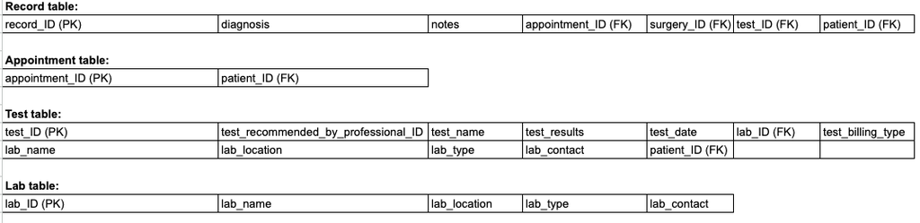

**3NF:** In order to be in 3NF, non non prime attribute should be transitiviely dependent on the primary key. In the 2NF, there exists transitive dependencies in the test table: Test table: test_ID -> lab_ID -> lab_name, lab_location, lab_type, lab_contact The following are the final modified tables in 3NF:

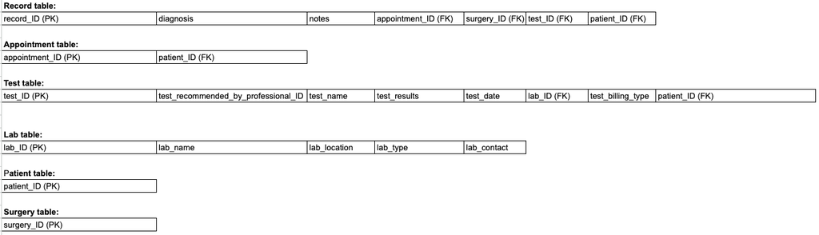

**Part c) Implement 3NF schema in SQLite database**

SQL statements used in SQLite to create the following tables:

**Create appointment table**

CREATE TABLE appointment ( appointment_ID TEXT PRIMARY KEY, patient_ID TEXT, appointment_time TEXT, appointment_status TEXT, appointment_date TEXT, professional_name TEXT, professional_role TEXT, department_ID TEXT, FOREIGN KEY (professional_role, professional_name, department_ID) REFERENCES professional(professional_role, professional_name, department_ID) );

INSERT INTO appointment SELECT appointment_ID, patient_id, appointment_time, appointment_status, appointment_date, professional_name, professional_role, department_ID FROM appointments_data WHERE appointment_ID IS NOT NULL GROUP BY appointment_ID;

**Create patient table:**

CREATE TABLE patient AS SELECT patient_ID, patient_name, patient_date_of_birth, patient_gender, patient_address, patient_preferred_hospital_ID, patient_preferred_pharmacy_ID, patient_preferred_insurance_provider from appointments_data WHERE patient_ID IS NOT NULL GROUP BY patient_ID

**Create hospital table**

CREATE TABLE hospital AS SELECT hospital_ID, hospital_name, hospital_location from appointments_data WHERE hospital_ID IS NOT NULL GROUP BY hospital_ID

**Create department table**

CREATE TABLE department AS SELECT department_ID, department_name, head_of_department, hospital_ID from appointments_data WHERE department_ID IS NOT NULL GROUP BY department_ID

**Create Professional table**

CREATE TABLE professional AS SELECT DISTINCT professional_role, professional_name, department_ID from appointments_data WHERE professional_role IS NOT NULL AND professional_name IS NOT NULL AND department_ID IS NOT NULL;

**Create emergency contact table**

CREATE TABLE emergencyContact AS SELECT emergency_contact_phone, emergency_contact_relationship, emergency_contact_name, emergency_contact_address from appointments_data WHERE emergency_contact_address IS NOT NULL GROUP BY emergency_contact_address;

**Create patient-emergency contact table**

CREATE TABLE patientEmergency AS SELECT DISTINCT patient_ID, emergency_contact_address from appointments_data WHERE patient_ID IS NOT NULL AND emergency_contact_address IS NOT NULL;

**Create pharmacy table**

CREATE TABLE pharmacy AS SELECT pharmacy_ID, pharmacy_name, pharmacy_location, pharmacy_contact, pharmacy_email, pharmacy_operating_hours, pharmacy_manager_name, pharmacy_website, pharmacy_services_offered from prescription_billing_insurance_data WHERE pharmacy_ID IS NOT NULL GROUP BY pharmacy_ID;

**Create mediction table**

CREATE TABLE medication AS SELECT medication_ID, medication_name, manufacturer, medication_dosage_form, medication_strength, medication_price from prescription_billing_insurance_data WHERE medication_ID IS NOT NULL GROUP BY medication_ID;

**Create insurance provider table**

CREATE TABLE insuranceProvider AS SELECT insurance_provider_ID, insurance_provider_name, insurance_provider_contact, insurance_provider_coverage_type from prescription_billing_insurance_data WHERE insurance_provider_ID IS NOT NULL GROUP BY insurance_provider_ID;

**Create Prescription Detail Table**

CREATE TABLE prescriptionDetail AS SELECT prescription_detail_ID, medication_dosage, medication_quantity, total_medication_billing_amount, dosage_start_date, dosage_end_date, prescription_ID, medication_ID from prescription_billing_insurance_data WHERE prescription_detail_ID IS NOT NULL GROUP BY prescription_detail_ID;

**Create surgery table**

CREATE TABLE surgery AS SELECT surgery_ID, surgery_professional_ID, patient_ID, surgery_hospital_ID, surgery_date, surgery_type, surgery_notes, surgery_post_operative_care, surgery_outcome from medical_surgeries_data WHERE surgery_ID IS NOT NULL GROUP BY surgery_ID;

**Create test table**

CREATE TABLE test AS SELECT test_ID, test_recommended_by_professional_ID, test_name, test_results, test_date, lab_ID, test_billing_type, patient_ID from medical_tests_data WHERE test_ID IS NOT NULL GROUP BY test_ID;

**Create lab table**

CREATE TABLE lab AS SELECT lab_ID, lab_name, lab_location, lab_type, lab_contact from medical_tests_data WHERE lab_ID IS NOT NULL GROUP BY lab_ID;

**Create service billing ID**

CREATE TABLE serviceBilling AS SELECT service_billing_ID, service_billing_amount, service_billing_amount_paid, service_billing_payment_date, service_billing_payment_status, appointment_ID, surgery_ID, test_ID from service_billing_insurance_data WHERE service_billing_ID IS NOT NULL GROUP BY service_billing_ID;

**Create claim table**

CREATE TABLE claim AS SELECT DISTINCT p.claim_id, p.claim_status, p.claim_status_reason, p.claim_amount, p.approved_amount, p.claim_date, p.approval_date, p.insurance_provider_ID, p.prescription_detail_ID, NULL AS service_billing_ID FROM prescription_billing_insurance_data p WHERE p.claim_id IS NOT NULL

UNION

SELECT DISTINCT s.claim_id, s.claim_status, s.claim_status_reason, s.claim_amount, s.approved_amount, s.claim_date, s.approval_date, s.insurance_provider_ID, NULL AS prescription_detail_ID,  
s.service_billing_ID FROM service_billing_insurance_data s WHERE s.claim_id IS NOT NULL;

**Create medical records table**

CREATE TABLE medicalRecords ( record_ID TEXT, diagnosis TEXT, notes TEXT, appointment_ID TEXT, surgery_ID TEXT, test_ID TEXT, patient_ID TEXT );

INSERT INTO medicalRecords (record_ID, diagnosis, notes, appointment_ID, surgery_ID, test_ID, patient_ID) SELECT record_ID, diagnosis, notes, appointment_ID, NULL AS surgery_ID, NULL AS test_ID, patient_ID FROM medical_appointments_data WHERE record_ID IS NOT NULL

UNION

SELECT record_ID, diagnosis, notes, NULL AS appointment_ID, surgery_ID, NULL AS test_ID, patient_ID FROM medical_surgeries_data WHERE record_ID IS NOT NULL

UNION

SELECT record_ID, diagnosis, notes, NULL AS appointment_ID, NULL AS surgery_ID, test_ID, patient_ID FROM medical_tests_data WHERE record_ID IS NOT NULL;

**Create prescription table**

CREATE TABLE Prescription AS SELECT DISTINCT pb.prescription_ID, pb.record_ID, pb.pharmacy_ID, ma.patient_ID, a.professional_name, a.professional_role FROM prescription_billing_insurance_data pb JOIN medical_appointments_data ma ON pb.record_ID = ma.record_ID JOIN appointments_data a ON ma.appointment_ID = a.appointment_ID WHERE prescription_ID IS NOT NULL;

Now, I will delete the rows with the duplicated title name that appeared when the tables were created in SQL.

```python
# Removing duplicate title columns

# Loading the claim csv file as a dataframe
con = sqlite3.connect("DATA Assessment.db")
cursor = con.cursor()

# Removing duplicate titles that was present in the sqlite tables when it was first created
cursor.execute("DELETE FROM claim WHERE claim_ID = ?", ("Claim_ID",))
con.commit()
con.close()
```

```python
# Loading the insuranceProvider csv file as a dataframe
con = sqlite3.connect("DATA Assessment.db")
cursor = con.cursor()

# Removing duplicate titles that was present in the sqlite tables when it was first created
cursor.execute("DELETE FROM insuranceProvider WHERE insurance_provider_ID = ?", ("Insurance_Provider_ID",))
con.commit()
con.close()
```

```python
# Loading the lab csv file as a dataframe
con = sqlite3.connect("DATA Assessment.db")
cursor = con.cursor()

# Removing duplicate titles
cursor.execute("DELETE FROM lab WHERE lab_ID = ?", ("Lab_ID",))
con.commit()
con.close()
```

```python
# Loading the medication csv file as a dataframe
con = sqlite3.connect("DATA Assessment.db")
cursor = con.cursor()

# Removing duplicate titles
cursor.execute("DELETE FROM medication WHERE Medication_ID = ?", ("Medication_ID",))
con.commit()
con.close()
```

```python
# Loading the patientEmergency csv file as a dataframe
con = sqlite3.connect("DATA Assessment.db")
cursor = con.cursor()

# Removing duplicate titles
cursor.execute("DELETE FROM patientEmergency WHERE patient_ID = ?", ("Patient_ID",))
con.commit()
con.close()
```

```python
# Loading the pharmacy csv file as a dataframe
con = sqlite3.connect("DATA Assessment.db")
cursor = con.cursor()

# Removing duplicate titles
cursor.execute("DELETE FROM pharmacy WHERE pharmacy_ID = ?", ("Pharmacy_ID",))
con.commit()
con.close()
```

```python
# Loading the professional csv file as a dataframe
con = sqlite3.connect("DATA Assessment.db")
cursor = con.cursor()

# Removing duplicate titles
cursor.execute("DELETE FROM professional WHERE professional_role = ?", ("Professional_Role",))
con.commit()
con.close()
```

```python
# Loading the serviceBilling csv file as a dataframe
con = sqlite3.connect("DATA Assessment.db")
cursor = con.cursor()

# Removing duplicate titles
cursor.execute("DELETE FROM serviceBilling WHERE service_billing_ID = ?", ("Service_Billing_ID",))
con.commit()
con.close()
```

## Task 3: Research Design, Implementation, and Results (45 Marks)

Using the database schema designed in Task 2, develop, implement, and analyse **three** distinct modelling solutions (**15 marks each**) to address the Data Intelligence team's aim (as described in the scenario). The three solutions must collectively cover all three of the following categories: inferential statistics, supervised learning, and unsupervised learning, with each solution primarily focusing on one or a combination of these categories. The solutions should be of sufficient complexity to demonstrate a comprehensive understanding of the data and the problem. For each solution, include:

- **Problem**: Clearly and concisely state the specific problem within the NHS context that your solution addresses.
- **Solution**: Detail the design of your solution, including the specific techniques used and how they are combined. Ensure that your design incorporates information from multiple tables in the database where relevant.
- **Justification**: Explain why the selected inferential statistics, supervised learning algorithms, and/or unsupervised learning algorithms are appropriate for the specific problem being addressed.
- **Implementation**: Provide well-commented and organised code (including SQL queries) used to implement your solution. Clearly indicate and justify any modifications made to the database schema or data. Ensure that your code is reproducible.
- **Results**: Present your findings in a clear and concise manner, using appropriate visualisations (charts, graphs, tables) as appropriate. Critically analyse your results, discussing how they can help the NHS address the stated problem.
- **Limitations**: Discuss any limitations of your solution, including potential biases in the data, assumptions made, or areas where the solution could be improved.

**World Limit**: 400 words per solution (1200 words in total for the three solutions). This limit applies only to the explanations. There is no limit on any associated code, commentary on the code, results generated as plots and tables, or figures.

**Write your answer here (text cell(s) to be used, as appropriate)**

```python
import pandas as pd
import sqlite3
import numpy as np
```

## Model solution 1: Supervised Learning for Patient Readmission

**Problem:** The NHS faces challenges in efficiently allocating hospital resources and improving patient outcomes. One factor that could be causing this is frequent patient readmissions as it may strain healthcare resources, and often indicates suboptimal care. Early identification of patients at risk of readmission can support hospital administrators to ensure sufficient staffing and resources.

**Solution:** To address this, I developed a machine learning model to predict whether a patient is likely to be readmitted within 30 days of a previous visit, a critical window for intervention. The model uses logistic regression, which I will first attempt to train on the following features:

- Visit results: Indicators of complications.
- Visit type: Certain procedures have higher post-operative risks.
- Patient gender: Some conditions are more prevalent in specific genders.
- Age at visit: Recovery rates vary with age.
- Diagnosis: Chronic conditions lead to repeated care.
- Number of previous visits: Frequent visits indicate chronic issues.
- Days since last visit: Short gaps may suggest ongoing health problems.

**Step 1: Loading the necessary datasets to extract the input features required for the model. The extracted input features will be stored in the dataframe, dfVisit**

```python
# Loading the appointment csv file as a dataframe
con = sqlite3.connect("DATA Assessment.db")
cursor = con.cursor()

# Removing duplicate titles that was present in the sqlite tables when it was first created
cursor.execute("DELETE FROM appointment WHERE appointment_ID = ?", ("Appointment_ID",))
con.commit()

dfAppointment = pd.read_sql_query("SELECT * FROM appointment", con)
con.close()
dfAppointment.head()
```

|  | appointment_ID | patient_ID | appointment_time | appointment_status | appointment_date | professional_name | professional_role | department_ID |
| --- | --- | --- | --- | --- | --- | --- | --- | --- |
| 0 | AP001 | P001 | 08:30 | Completed | 2024-04-09 | Michelle Griffiths | Virologist | D2210 |
| 1 | AP002 | P002 | 19:30 | Completed | 2024-07-30 | Ms Shannon Hawkins | Physiotherapist | D1357 |
| 2 | AP003 | P003 | 18:50 | Completed | 2024-09-18 | Rachael Cox | Oncology Nurse | D1114 |
| 3 | AP004 | P004 | 14:50 | Scheduled | 2025-07-09 | Henry Doherty | Paramedic | D138 |
| 4 | AP005 | P005 | 16:20 | Completed | 2024-02-27 | Ms Samantha Ahmed | Neurologist | D3119 |

```python
# Loading the surgery csv file as a dataframe
con = sqlite3.connect("DATA Assessment.db")
cursor = con.cursor()
cursor.execute("DELETE FROM surgery WHERE surgery_ID = ?", ("Surgery_ID",))
con.commit()

dfSurgery = pd.read_sql_query("SELECT * FROM surgery", con)
con.close()
dfSurgery.head()
```

|  | surgery_ID | surgery_professional_ID | patient_ID | surgery_hospital_ID | surgery_date | surgery_type | surgery_notes | surgery_post_operative_care | surgery_outcome |
| --- | --- | --- | --- | --- | --- | --- | --- | --- | --- |
| 0 | SG001 | PR28093 | P327281 | H216 | 2024-05-07 | Bladder Cancer Resection | Transurethral resection of bladder tumor (TURB... | Monitor for changes in urinary habits. Drink p... | Infection |
| 1 | SG002 | PR3062 | P277060 | H171 | 2025-01-21 | Gastrectomy | Partial gastrectomy performed for gastric canc... | Gradual introduction to solid foods. Follow-up... | Complications |
| 2 | SG003 | PR9918 | P358930 | H004 | 2025-02-26 | C-section | Emergency C-section due to fetal distress. APG... | Avoid strenuous activity for 4 weeks. Watch fo... | Recovered |
| 3 | SG004 | PR23683 | P90460 | H182 | 2024-08-24 | Thyroidectomy | Total thyroidectomy performed due to thyroid c... | Monitor calcium levels post-op. Follow-up appo... | Partial Success |
| 4 | SG005 | PR25283 | P292996 | H239 | 2025-01-08 | Ureteral Stent Placement | Ureteral stent placed successfully to relieve ... | Follow-up imaging in 2 weeks to assess stent p... | Unsuccessful |

```python
# Getting the test dataframe
con = sqlite3.connect("DATA Assessment.db")
cursor = con.cursor()
cursor.execute("DELETE FROM test WHERE test_ID = ?", ("Test_ID",))
con.commit()

dfTest = pd.read_sql_query("SELECT * FROM test", con)
con.close()
dfTest.head()
```

|  | test_ID | test_recommended_by_professional_ID | test_name | test_results | test_date | lab_ID | test_billing_type | patient_ID |
| --- | --- | --- | --- | --- | --- | --- | --- | --- |
| 0 | T001 | PR28008 | Forensic Testing | Substance detected | 2024-08-13 | L256 | NHS | P022 |
| 1 | T002 | PR28008 | Nutrition Assessment | Malnutrition | 2024-10-23 | L262 | NHS | P022 |
| 2 | T003 | PR28008 | Hormone Test | Thyroid imbalance | 2025-02-19 | L106 | NHS | P022 |
| 3 | T004 | PR28008 | Kidney Function Test | Normal | 2024-07-27 | L082 | NHS | P022 |
| 4 | T005 | PR28008 | Blood Test | Vitamin deficiency | 2025-02-14 | L421 | NHS | P022 |

```python
# Create dfTestVisit table to extract patient_ID, visit_ID, visit_results and visit_date for a test visit type

dfTestVisit = dfTest[['patient_ID', 'test_ID', 'test_results', 'test_date']].copy()

dfTestVisit.rename(columns={
    'test_ID': 'visit_ID',
    'test_results': 'visit_results',
    'test_date': 'visit_date'
}, inplace=True)

dfTestVisit['visit_type'] = 'test'

dfTestVisit.head()
```

|  | patient_ID | visit_ID | visit_results | visit_date | visit_type |
| --- | --- | --- | --- | --- | --- |
| 0 | P022 | T001 | Substance detected | 2024-08-13 | test |
| 1 | P022 | T002 | Malnutrition | 2024-10-23 | test |
| 2 | P022 | T003 | Thyroid imbalance | 2025-02-19 | test |
| 3 | P022 | T004 | Normal | 2024-07-27 | test |
| 4 | P022 | T005 | Vitamin deficiency | 2025-02-14 | test |

```python
# Create dfAppVisit table to extract patient_ID, visit_ID, visit_results and visit_date for an appointment visit type
# Only extracts appointment data where the appointment_status is completed

dfAppVisit = dfAppointment[dfAppointment["appointment_status"] == "Completed"][["patient_ID", "appointment_ID", "appointment_date"]].copy()

dfAppVisit.rename(columns={
    'appointment_ID': 'visit_ID',
    'appointment_date': 'visit_date'
}, inplace=True)

dfAppVisit['visit_results'] = None
dfAppVisit['visit_type'] = 'appointment'
dfAppVisit.head()
```

|  | patient_ID | visit_ID | visit_date | visit_results | visit_type |
| --- | --- | --- | --- | --- | --- |
| 0 | P001 | AP001 | 2024-04-09 | None | appointment |
| 1 | P002 | AP002 | 2024-07-30 | None | appointment |
| 2 | P003 | AP003 | 2024-09-18 | None | appointment |
| 4 | P005 | AP005 | 2024-02-27 | None | appointment |
| 5 | P006 | AP006 | 2024-04-09 | None | appointment |

```python
# Create dfSurgVisit table to extract patient_ID, visit_ID, visit_results and visit_date for a surgery visit type

dfSurgVisit = dfSurgery[['patient_ID', 'surgery_ID', 'surgery_outcome', 'surgery_date']].copy()

dfSurgVisit.rename(columns={
    'surgery_ID': 'visit_ID',
    'surgery_date': 'visit_date',
    'surgery_outcome': 'visit_results'
}, inplace=True)

dfSurgVisit['visit_type'] = 'surgery'
dfSurgVisit.head()
```

|  | patient_ID | visit_ID | visit_results | visit_date | visit_type |
| --- | --- | --- | --- | --- | --- |
| 0 | P327281 | SG001 | Infection | 2024-05-07 | surgery |
| 1 | P277060 | SG002 | Complications | 2025-01-21 | surgery |
| 2 | P358930 | SG003 | Recovered | 2025-02-26 | surgery |
| 3 | P90460 | SG004 | Partial Success | 2024-08-24 | surgery |
| 4 | P292996 | SG005 | Unsuccessful | 2025-01-08 | surgery |

```python
# Combine surgery, appointment and test visit tables into 1 table called dfVisit
dfVisit = pd.concat([dfTestVisit, dfAppVisit, dfSurgVisit], ignore_index=True)

dfVisit.reset_index(drop=True, inplace=True)
dfVisit.head()
```

|  | patient_ID | visit_ID | visit_results | visit_date | visit_type |
| --- | --- | --- | --- | --- | --- |
| 0 | P022 | T001 | Substance detected | 2024-08-13 | test |
| 1 | P022 | T002 | Malnutrition | 2024-10-23 | test |
| 2 | P022 | T003 | Thyroid imbalance | 2025-02-19 | test |
| 3 | P022 | T004 | Normal | 2024-07-27 | test |
| 4 | P022 | T005 | Vitamin deficiency | 2025-02-14 | test |

```python
# Identifiying the datatype of visit_date
print(dfVisit["visit_date"].dtype)
```

```
object
```

```python
# Tranforming the visit_date type as datetime format for sorting
dfVisit["visit_date"] = pd.to_datetime(dfVisit["visit_date"], errors="coerce")
```

```python
# Confirming the datatype of visit_date
print(dfVisit["visit_date"].dtype)
```

```
datetime64[ns]
```

```python
# Adding revisited_within_30_days column into dfVisit

dfVisit = dfVisit.sort_values(by=["patient_ID", "visit_date"]).reset_index(drop=True)

dfVisit["revisited_within_30_days"] = 0

# Calculates if a patient revisits in 30 days
for i in range(len(dfVisit) - 1):
    # Check if the next visit for the same patient is within 30 days
    current_patient = dfVisit.loc[i, "patient_ID"]
    current_date = dfVisit.loc[i, "visit_date"]
    next_patient = dfVisit.loc[i + 1, "patient_ID"]
    next_date = dfVisit.loc[i + 1, "visit_date"]

    if current_patient == next_patient and (next_date - current_date).days <= 30:
        dfVisit.loc[i, "revisited_within_30_days"] = 1

dfVisit.head()
```

|  | patient_ID | visit_ID | visit_results | visit_date | visit_type | revisited_within_30_days |
| --- | --- | --- | --- | --- | --- | --- |
| 0 | P001 | AP001 | None | 2024-04-09 | appointment | 0 |
| 1 | P001 | SG43872 | Partial Success | 2025-01-31 | surgery | 0 |
| 2 | P002 | AP002 | None | 2024-07-30 | appointment | 0 |
| 3 | P003 | AP003 | None | 2024-09-18 | appointment | 0 |
| 4 | P005 | AP005 | None | 2024-02-27 | appointment | 0 |

```python
# Loading the patient table as a dataframe

con = sqlite3.connect("DATA Assessment.db")
cursor = con.cursor()
cursor.execute("DELETE FROM patient WHERE patient_ID = ?", ("Patient_ID",)) # Removing duplicate titles
con.commit()

dfPatient = pd.read_sql_query("SELECT * FROM patient", con)
con.close()
dfPatient.head()
```

|  | patient_ID | patient_name | patient_date_of_birth | patient_gender | patient_address | patient_preferred_hospital_ID | patient_preferred_pharmacy_ID | patient_preferred_insurance_provider |
| --- | --- | --- | --- | --- | --- | --- | --- | --- |
| 0 | P001 | Brandon Lawson | 1938-07-11 | F | Flat 86\nButler ports, Derby, N08 8HG | H192 | PH562 | None |
| 1 | P002 | June Williams | 1967-05-13 | F | 95 Kathleen mall, Luton, WA8 2RD | H207 | PH756 | None |
| 2 | P003 | Dr Oliver Jackson | 1974-05-07 | M | Studio 7\nLeah shores, Nottingham, G79 1BE | H106 | PH684 | IP09 |
| 3 | P004 | Leanne Khan-Price | 1983-08-27 | M | 41 Jones extension, Southend-on-Sea, E5 4NN | H013 | PH496 | IP27 |
| 4 | P005 | Suzanne Lloyd | 2003-09-10 | M | 618 Bevan flats, Wokingham, CB4 4TL | H251 | PH928 | None |

```python
# Adding patient_gender in dfVisit
if 'patient_gender' not in dfVisit.columns:
    dfVisit = dfVisit.merge(dfPatient[['patient_ID', 'patient_gender']], on='patient_ID', how='left')
```

```python
# Adding patient_date_of_birth in dfVisit to caculate patient's age at visit

if 'patient_date_of_birth' not in dfVisit.columns:
    dfVisit = dfVisit.merge(dfPatient[['patient_ID', 'patient_date_of_birth']], on='patient_ID', how='left')
    dfVisit['patient_date_of_birth'] = pd.to_datetime(dfVisit['patient_date_of_birth'])
```

```python
# Adding the patient's age at visit in dfVisit

if 'age_at_visit' not in dfVisit.columns:
    dfVisit['age_at_visit'] = (dfVisit['visit_date'] - dfVisit['patient_date_of_birth']).dt.days // 365

    #Delete patient_date_of_birth column as not needed anymore
    dfVisit.drop(columns=['patient_date_of_birth'], inplace=True)

dfVisit.head()
```

|  | patient_ID | visit_ID | visit_results | visit_date | visit_type | revisited_within_30_days | patient_gender | age_at_visit |
| --- | --- | --- | --- | --- | --- | --- | --- | --- |
| 0 | P001 | AP001 | None | 2024-04-09 | appointment | 0 | F | 85 |
| 1 | P001 | SG43872 | Partial Success | 2025-01-31 | surgery | 0 | F | 86 |
| 2 | P002 | AP002 | None | 2024-07-30 | appointment | 0 | F | 57 |
| 3 | P003 | AP003 | None | 2024-09-18 | appointment | 0 | M | 50 |
| 4 | P005 | AP005 | None | 2024-02-27 | appointment | 0 | M | 20 |

```python
# Loading the medicalRecords table as a dataframe
con = sqlite3.connect("DATA Assessment.db")
cursor = con.cursor()
cursor.execute("DELETE FROM medicalRecords WHERE record_ID = ?", ("Record_ID",)) # Removing duplicate titles
con.commit()

dfRecords = pd.read_sql_query("SELECT * FROM medicalRecords", con)
con.close()
dfRecords.head()
```

|  | record_ID | diagnosis | notes | appointment_ID | surgery_ID | test_ID | patient_ID |
| --- | --- | --- | --- | --- | --- | --- | --- |
| 0 | MR001 | Tension Headache | ['Frequent headaches reported. Recommended hyd... | AP001 | None | None | P001 |
| 1 | MR002 | Routine Health Checkup | Routine check-up, patient reports no major con... | AP002 | None | None | P002 |
| 2 | MR003 | Routine Health Checkup | General wellness check-up, patient has no new ... | AP003 | None | None | P003 |
| 3 | MR004 | Gastric Discomfort | ['Patient experiencing acid reflux. Advised di... | AP005 | None | None | P005 |
| 4 | MR005 | Irritable Bowel Syndrome | ['Patient experiences bloating and cramps. Sug... | AP006 | None | None | P006 |

```python
# Create a diagnosis dataframe for each visit_ID
diagnosis = pd.melt(
    dfRecords[['diagnosis', 'appointment_ID', 'surgery_ID', 'test_ID']],
    id_vars=['diagnosis'],
    value_name='visit_ID'
).dropna()

# Add diagnosis column in dfVisit
if 'diagnosis' not in dfVisit.columns:
    dfVisit = dfVisit.merge(
        diagnosis[['diagnosis', 'visit_ID']],
        on='visit_ID',
        how='left'
    )

dfVisit.head()
```

|  | patient_ID | visit_ID | visit_results | visit_date | visit_type | revisited_within_30_days | patient_gender | age_at_visit | diagnosis |
| --- | --- | --- | --- | --- | --- | --- | --- | --- | --- |
| 0 | P001 | AP001 | None | 2024-04-09 | appointment | 0 | F | 85 | Tension Headache |
| 1 | P001 | SG43872 | Partial Success | 2025-01-31 | surgery | 0 | F | 86 | Hysterectomy |
| 2 | P002 | AP002 | None | 2024-07-30 | appointment | 0 | F | 57 | Routine Health Checkup |
| 3 | P003 | AP003 | None | 2024-09-18 | appointment | 0 | M | 50 | Routine Health Checkup |
| 4 | P005 | AP005 | None | 2024-02-27 | appointment | 0 | M | 20 | Gastric Discomfort |

```python
# Adds the total number of previous visits (num_previous_visits) a patient has had in dfVisits

if 'num_previous_visits' not in dfVisit.columns:
    dfVisit["num_previous_visits"] = dfVisit.groupby("patient_ID").cumcount()
dfVisit.head()
```

|  | patient_ID | visit_ID | visit_results | visit_date | visit_type | revisited_within_30_days | patient_gender | age_at_visit | diagnosis | num_previous_visits |
| --- | --- | --- | --- | --- | --- | --- | --- | --- | --- | --- |
| 0 | P001 | AP001 | None | 2024-04-09 | appointment | 0 | F | 85 | Tension Headache | 0 |
| 1 | P001 | SG43872 | Partial Success | 2025-01-31 | surgery | 0 | F | 86 | Hysterectomy | 1 |
| 2 | P002 | AP002 | None | 2024-07-30 | appointment | 0 | F | 57 | Routine Health Checkup | 0 |
| 3 | P003 | AP003 | None | 2024-09-18 | appointment | 0 | M | 50 | Routine Health Checkup | 0 |
| 4 | P005 | AP005 | None | 2024-02-27 | appointment | 0 | M | 20 | Gastric Discomfort | 0 |

```python
# Load prescription table as dataframe

con = sqlite3.connect("DATA Assessment.db")
cursor = con.cursor()
cursor.execute("DELETE FROM prescription WHERE prescription_ID = ?", ("Prescription_ID",)) # Removing duplicate titles
con.commit()

dfPrescription = pd.read_sql_query("SELECT * FROM prescription", con)
con.close()
dfPrescription.head()
```

|  | prescription_ID | record_ID | pharmacy_ID | patient_ID | professional_name | professional_role |
| --- | --- | --- | --- | --- | --- | --- |
| 0 | PC004 | MR017 | PH186 | P020 | Gordon Day | Junior Doctor |
| 1 | PC013 | MR095 | PH474 | P088 | Marion Blake | Orthopaedic Technician |
| 2 | PC018 | MR134 | PH491 | P125 | Mr Gareth Adams | A&E Consultant |
| 3 | PC019 | MR151 | PH498 | P140 | Dr Christian Elliott | Chaplain |
| 4 | PC025 | MR189 | PH378 | P167 | Abdul White | Microbiologist |

```python
# Load prescriptionDetail table as dataframe

con = sqlite3.connect("DATA Assessment.db")
cursor = con.cursor()
cursor.execute("DELETE FROM prescriptionDetail WHERE prescription_detail_ID = ?", ("Prescription_Detail_ID",)) # Removing duplicate titles
con.commit()

dfPrescriptionDetail = pd.read_sql_query("SELECT * FROM prescriptionDetail", con)
con.close()
dfPrescriptionDetail.head()
```

|  | prescription_detail_ID | medication_dosage | medication_quantity | total_medication_billing_amount | dosage_start_date | dosage_end_date | prescription_ID | medication_ID |
| --- | --- | --- | --- | --- | --- | --- | --- | --- |
| 0 | PCD006 | 500mg once a week | 2 | 1475.7 | 2024-07-12 | 2024-11-04 | PC004 | M109737 |
| 1 | PCD019 | 100mg every two weeks | 2 | 1290.28 | 2024-10-16 | 2025-01-08 | PC013 | M27452 |
| 2 | PCD020 | 100mg/ml twice a week | 3 | 167.31 | 2024-10-16 | 2024-12-03 | PC013 | M43376 |
| 3 | PCD021 | 500mg once a day | 5 | 25.8 | 2024-10-16 | 2025-01-14 | PC013 | M101341 |
| 4 | PCD022 | One puff of 250mcg twice a day | 1 | 32.21 | 2024-10-16 | 2024-10-16 | PC013 | M5839 |

```python
dfVisit.sort_values(by=["patient_ID", "visit_date"], inplace=True)

# Add days since last visit (days_since_last_visit) in dfVisit

if 'days_since_last_visit' not in dfVisit.columns:
    dfVisit["days_since_last_visit"] = dfVisit.groupby("patient_ID")["visit_date"].diff().dt.days

# Replace NaN (first visit) with 0
dfVisit["days_since_last_visit"] = dfVisit["days_since_last_visit"].fillna(-1)

dfVisit.head()
```

|  | patient_ID | visit_ID | visit_results | visit_date | visit_type | revisited_within_30_days | patient_gender | age_at_visit | diagnosis | num_previous_visits | days_since_last_visit |
| --- | --- | --- | --- | --- | --- | --- | --- | --- | --- | --- | --- |
| 0 | P001 | AP001 | None | 2024-04-09 | appointment | 0 | F | 85 | Tension Headache | 0 | -1.0 |
| 1 | P001 | SG43872 | Partial Success | 2025-01-31 | surgery | 0 | F | 86 | Hysterectomy | 1 | 297.0 |
| 2 | P002 | AP002 | None | 2024-07-30 | appointment | 0 | F | 57 | Routine Health Checkup | 0 | -1.0 |
| 3 | P003 | AP003 | None | 2024-09-18 | appointment | 0 | M | 50 | Routine Health Checkup | 0 | -1.0 |
| 4 | P005 | AP005 | None | 2024-02-27 | appointment | 0 | M | 20 | Gastric Discomfort | 0 | -1.0 |

**Step 2: Prepare data for machine learning model**

Encode and scale data

```python
from sklearn.preprocessing import LabelEncoder, StandardScaler

dfVisit1 = dfVisit.copy()
# Tranform categorical datatypes to integer type as logistic regression can only take integer type input
label_encoders = {}
for col in ["patient_gender", "visit_type", "diagnosis", "visit_results"]:
    le = LabelEncoder()
    dfVisit1[col] = le.fit_transform(dfVisit1[col].astype(str))
    label_encoders[col] = le
```

```python
# Scale numerical features for better performance

numerical_features = ["age_at_visit", "days_since_last_visit", "num_previous_visits"]
scaler = StandardScaler()
dfVisit1[numerical_features] = scaler.fit_transform(dfVisit1[numerical_features])
```

Preparing training and test set

```python
from sklearn.model_selection import train_test_split

# X = input features, y = label
X = dfVisit1.drop(columns=["revisited_within_30_days", "patient_ID", "visit_ID", "visit_date"])
y = dfVisit1["revisited_within_30_days"]

# Split data into 80% training and 20% test sets
X_train, X_test, y_train, y_test = train_test_split(X, y, test_size=0.2, random_state=42, stratify=y)
```

```python
# Seeing what is there in X_train
X_train.head()
```

|  | visit_results | visit_type | patient_gender | age_at_visit | diagnosis | num_previous_visits | days_since_last_visit |
| --- | --- | --- | --- | --- | --- | --- | --- |
| 506285 | 48 | 0 | 0 | -0.264602 | 31 | -0.525682 | -0.483871 |
| 582298 | 48 | 0 | 0 | -0.122430 | 50 | -0.525682 | -0.483871 |
| 136288 | 48 | 0 | 1 | 0.398865 | 116 | 0.405463 | 1.312611 |
| 550805 | 48 | 0 | 0 | 0.256694 | 116 | -0.215300 | 0.396757 |
| 132906 | 48 | 0 | 1 | -0.785897 | 127 | -0.525682 | -0.483871 |

**Step 3: Train the logistic regression model with the training set**

```python
from sklearn.linear_model import LogisticRegression

logistic_regression_model = LogisticRegression(max_iter=1000, random_state=42)

# Train the model
logistic_regression_model.fit(X_train, y_train)
```

```
LogisticRegression(max_iter=1000, random_state=42)
```

**Step 4: Test the trained model using the test dataset**

```python
prediction = logistic_regression_model.predict(X_test)
```

Evaluate the logistic regression model

```python
#Calculate the intercept and regression coefficients

intercept = logistic_regression_model.intercept_
print("intercept: ", intercept[0])
coeff = logistic_regression_model.coef_
print("(feature) : (coefficent)")
print("visit_results: ",coeff[0][0])
print("visit_type: ",coeff[0][1])
print("patient_gender: ",coeff[0][2])
print("age_at_visit: ",coeff[0][3])
print("diagnosis: ",coeff[0][4])
print("num_previous_visits: ",coeff[0][5])
print("days_since_last_visit: ",coeff[0][6])
```

```
intercept:  -1.5173682150884313
(feature) : (coefficent)
visit_results:  -0.004679751213113549
visit_type:  0.5268841540379643
patient_gender:  -0.010644185042668319
age_at_visit:  0.0035917780648524276
diagnosis:  0.0006933609592223627
num_previous_visits:  0.7102230726826467
days_since_last_visit:  -0.20243464706267658
```

**Interprating the intercept:**

- Negative intercept (-1.5) = The model is biased towards predicting no readmission (0) by default

**Observation from coefficients:**

- Features that has strong/moderate influence to the final readmission prediction = Patient's number of previous visits (0.71), visit type (0.52) and days since last visit (-0.2)
- Features that has weak influence to the final readmission prediction = Patient's visit results (-0.004), age at visit (0.003), gender (-0.01) and diagnosis (0.00069, very weak)

**Step 5: Evaluating the logistic regression model**

```python
# Evaluate model using confusion matrix

from sklearn.metrics import confusion_matrix
confusion_matrix(y_test, prediction)
```

```
array([[90478,  3162],
       [18538,  6370]])
```

```python
# Calculate accuracy

from sklearn.metrics import accuracy_score
model_accuracy = accuracy_score(y_test, prediction)
model_accuracy
```

```
0.816951783243918
```

```python
# Checking precision, recall and F1 score

from sklearn.metrics import classification_report
print(classification_report(y_test, prediction))
```

```
              precision    recall  f1-score   support

           0       0.83      0.97      0.89     93640
           1       0.67      0.26      0.37     24908

    accuracy                           0.82    118548
   macro avg       0.75      0.61      0.63    118548
weighted avg       0.80      0.82      0.78    118548
```

Observation for class 1 (readmitted):

- precision = 0.67 --> When model predicts readmitted, only 67% is correct
- f1-score = 0.37 --> really low suggesting poor model performance
- recall = 0.26 --> Only catches 26% of the actual readmitted cases

**Attempt 2 at creating a better machine learning model**

```python
# Investigating if there is a class imbalance
print(dfVisit["revisited_within_30_days"].value_counts())
```

```
revisited_within_30_days
0    468199
1    124538
Name: count, dtype: int64
```

Observation: Significant class imbalance ratio! Almost 4 times as many non-readmissions than readmissions.

Handling the significant class imbalance in the dataset:

```python
from imblearn.over_sampling import SMOTE
from imblearn.under_sampling import RandomUnderSampler

# Oversample readmitted class
smote = SMOTE(random_state=42)
X_train_balanced, y_train_balance = smote.fit_resample(X_train, y_train)

# Undersample not readmitted class
rus = RandomUnderSampler(random_state=42)
X_train_balanced, y_train_balanced = rus.fit_resample(X_train, y_train)
```

```python
# Training the 2nd logisticl regression model

logistic_regression_model2 = LogisticRegression(max_iter=1000, random_state=42, class_weight='balanced')
logistic_regression_model2.fit(X_train_balanced, y_train_balanced)
```

```
LogisticRegression(class_weight='balanced', max_iter=1000, random_state=42)
```

```python
# Test trained model using test dataset
model2_prediction = logistic_regression_model2.predict(X_test)

# Checking accuracy
model2_accuracy = accuracy_score(y_test, model2_prediction)
print("Accuracy of 2nd logistic regression model: ", model2_accuracy)
```

```
Accuracy of 2nd logistic regression model:  0.7892330532779971
```

```python
# Checking precision, recall and F1 score of 2nd model

print(classification_report(y_test, model2_prediction))
```

```
              precision    recall  f1-score   support

           0       0.89      0.84      0.86     93640
           1       0.50      0.60      0.54     24908

    accuracy                           0.79    118548
   macro avg       0.69      0.72      0.70    118548
weighted avg       0.81      0.79      0.80    118548
```

Observation for class 1 (readmitted):

The performance of the model is still not desirable, so I will attempt to improve the model by adding different featues.

**Attempt 3: Training the model on new set of features**

I will now consider adding a chronic patient indicator as a feature.

Assume the list of chronic diseases can be based on the examples from the NHS website.

- NHS chronic disease list = https://blackcountry.icb.nhs.uk/your-health/health-advice/long-term-conditions

```python
chronic_keywords = ["asthma", "copd", "cancer", "hiv", "heart", "chronic kidney disease", "coronary", "hypertension", "stroke", "chronic"]

# Normalize diagnosis text to lowercase
dfVisit["diagnosis"] = dfVisit["diagnosis"].fillna("").str.lower()

# Create chronic_flag
if 'chronic_flag' not in dfVisit.columns:
    dfVisit["chronic_flag"] = dfVisit["diagnosis"].apply(
        lambda x: int(any(keyword in x for keyword in chronic_keywords))
    )

dfChronicPatient = dfVisit.groupby("patient_ID")["chronic_flag"].max().reset_index()

# Add chronic_flag into dfVisit
if 'chronic_flag' not in dfVisit.columns:
    dfVisit = dfVisit.merge(dfChronicPatient, on="patient_ID", how="left")

dfVisit.head()
```

|  | patient_ID | visit_ID | visit_results | visit_date | visit_type | revisited_within_30_days | patient_gender | age_at_visit | diagnosis | num_previous_visits | days_since_last_visit | chronic_flag |
| --- | --- | --- | --- | --- | --- | --- | --- | --- | --- | --- | --- | --- |
| 0 | P001 | AP001 | None | 2024-04-09 | appointment | 0 | F | 85 | tension headache | 0 | -1.0 | 0 |
| 1 | P001 | SG43872 | Partial Success | 2025-01-31 | surgery | 0 | F | 86 | hysterectomy | 1 | 297.0 | 0 |
| 2 | P002 | AP002 | None | 2024-07-30 | appointment | 0 | F | 57 | routine health checkup | 0 | -1.0 | 0 |
| 3 | P003 | AP003 | None | 2024-09-18 | appointment | 0 | M | 50 | routine health checkup | 0 | -1.0 | 0 |
| 4 | P005 | AP005 | None | 2024-02-27 | appointment | 0 | M | 20 | gastric discomfort | 0 | -1.0 | 0 |

Training the model on new features

```python
# New dfVisit

dfVisit2 = dfVisit.copy()
```

```python
# Tranform categorical datatypes to integer type
label_encoders = {}
le = LabelEncoder()
dfVisit2["visit_type"] = le.fit_transform(dfVisit2["visit_type"].astype(str))
label_encoders["visit_type"] = le

# Scale numerical features
numerical_features = ["days_since_last_visit", "num_previous_visits"]
scaler = StandardScaler()
dfVisit2[numerical_features] = scaler.fit_transform(dfVisit2[numerical_features])
```

Drop features that does not have significant impact on model

```python
# X = input features, y = label
X = dfVisit2.drop(columns=["revisited_within_30_days", "patient_ID", "visit_ID", "visit_date", "diagnosis", "visit_results", "age_at_visit", "patient_gender"])
y = dfVisit2["revisited_within_30_days"]

# Split data into 80% training and 20% test sets
X_train, X_test, y_train, y_test = train_test_split(X, y, test_size=0.2, random_state=42, stratify=y)
```

```python
# Oversample readmitted class
smote = SMOTE(random_state=42)
X_train_balanced, y_train_balance = smote.fit_resample(X_train, y_train)

# Undersample not readmitted class
rus = RandomUnderSampler(random_state=42)
X_train_balanced, y_train_balanced = rus.fit_resample(X_train, y_train)
```

```python
# Training the 3rd logistic regression model

logistic_regression_model3 = LogisticRegression(max_iter=1000, random_state=42, class_weight='balanced')
logistic_regression_model3.fit(X_train_balanced, y_train_balanced)
```

```
LogisticRegression(class_weight='balanced', max_iter=1000, random_state=42)
```

```python
# test trained model using test dataset
model3_prediction = logistic_regression_model3.predict(X_test)

# Checking accuracy
model3_accuracy = accuracy_score(y_test, model3_prediction)
model3_accuracy
```

```
0.7947835475925363
```

```python
#Calculate the intercept and regression coefficients

intercept = logistic_regression_model3.intercept_
print("intercept: ", intercept[0])
coeff = logistic_regression_model3.coef_
print("(feature) : (coefficent)")
print("visit_type: ",coeff[0][0])
print("num_previous_visits: ",coeff[0][1])
print("days_since_last_visit: ",coeff[0][2])
print("chronic_flag: ",coeff[0][3])
```

```
intercept:  -0.3770271181124238
(feature) : (coefficent)
visit_type:  0.4692368062713414
num_previous_visits:  0.8399137449498406
days_since_last_visit:  -0.18456752001776436
chronic_flag:  0.13480123069614647
```

```python
# Checking precision, recall and F1 score

print(classification_report(y_test, model3_prediction))
```

```
              precision    recall  f1-score   support

           0       0.89      0.85      0.87     93640
           1       0.51      0.60      0.55     24908

    accuracy                           0.79    118548
   macro avg       0.70      0.72      0.71    118548
weighted avg       0.81      0.79      0.80    118548
```

**Results:**

The final Logistic Regression model (Model 3) used visit type, number of previous visits, days since last visit, and chronic flag as features. Initially, features like visit results, patient gender, age at visit, and diagnosis were considered but later excluded after their coefficients showed minimal impact, reducing potential noise.

The num_previous_visits emerged as the most influential feature (0.839), indicating patients with a higher number of previous visits are significantly more likely to be readmitted.

The model effectively predicted non-readmissions (Class 0) with 0.89 precision and 0.87 f1-score, but struggled with readmissions (Class 1), achieving only 0.51 precision and 0.55 f1-score.

Although this model improved over model 1 by addressing class imbalance, it showed comparable performance to model 2, even after adding the chronic flag. Therefore, this model can support the NHS in predicting patients that may not be readmitted but it may struggle to accurately identify patient readmissions.

**Limitations:**

The model remains sensitive to class imbalance. It lacks clinical features, limiting its ability to capture readmission risk accurately.

## Model solution 2: Inferential Statistics for Analyzing Effectiveness of Medical Intervensions

**Problem:** The NHS aims to optimize patient outcomes and improve healthcare delivery across different hospital types. One way to investigate this is by questioning whether private hospital types typically achieve better surgical success rates than NHS hospitals, which could guide future resource allocation and quality improvement efforts, and reveal if the medical quality of NHS hospitals is lower than in private hospitals.

**Solution:** To analyze if the surgery outcomes differ from hospital type, I will randomly select 10 hospitals of NHS and private hospital type each, and use a Chi-Square Test of Independence to assess whether their surgical success rates differ significantly.

- Null Hypothesis (H0): There is no significant difference in the proportion of successful surgery outcomes between NHS Hospitals and Private Hospitals, such that the success rates are independent of hospital type.

(*H0: P of NHS Hospitals = P of Private Hospitals*)

- Alternative Hypothesis (H1): There is a significant difference in the proportion of successful surgery outcomes between NHS Hospitals and Private Hospitals, such that the success rates depend on the hospital type. (*H1: P of NHS Hospitals != P of Private Hospitals*)

**Justification:** The Chi-Square Test of Independence was chosen because it’s a non-parametric test which is suitable for categorical data (successful outcomes vs unsuccessful outcomes), which allows for comparison of proportions across groups without assuming a normal distribution.

Randomly sampling 10 hospitals from each type and selecting those with records of 200-500 surgeries ensures a fair and balanced comparison. This approach allows the analysis to avoid bias from extremely high or low surgery counts while maintaining adequate sample size for Chi-Square testing. Random sampling also helps reduce selection bias. Overall, it offers a representative selection of surgery outcomes across both hospital types without over generalising from a single hospital.

```python
dfSurgeryRenamed = dfSurgery.copy()

# Rename column surgery_hospital_ID to hospital_ID for cohesiveness
dfSurgeryRenamed.rename(columns={'surgery_hospital_ID': 'hospital_ID'}, inplace=True)
dfSurgeryRenamed.head()
```

|  | surgery_ID | surgery_professional_ID | patient_ID | hospital_ID | surgery_date | surgery_type | surgery_notes | surgery_post_operative_care | surgery_outcome |
| --- | --- | --- | --- | --- | --- | --- | --- | --- | --- |
| 0 | SG001 | PR28093 | P327281 | H216 | 2024-05-07 | Bladder Cancer Resection | Transurethral resection of bladder tumor (TURB... | Monitor for changes in urinary habits. Drink p... | Infection |
| 1 | SG002 | PR3062 | P277060 | H171 | 2025-01-21 | Gastrectomy | Partial gastrectomy performed for gastric canc... | Gradual introduction to solid foods. Follow-up... | Complications |
| 2 | SG003 | PR9918 | P358930 | H004 | 2025-02-26 | C-section | Emergency C-section due to fetal distress. APG... | Avoid strenuous activity for 4 weeks. Watch fo... | Recovered |
| 3 | SG004 | PR23683 | P90460 | H182 | 2024-08-24 | Thyroidectomy | Total thyroidectomy performed due to thyroid c... | Monitor calcium levels post-op. Follow-up appo... | Partial Success |
| 4 | SG005 | PR25283 | P292996 | H239 | 2025-01-08 | Ureteral Stent Placement | Ureteral stent placed successfully to relieve ... | Follow-up imaging in 2 weeks to assess stent p... | Unsuccessful |

```python
# Loading the hospital csv file as a dataframe
con = sqlite3.connect("DATA Assessment.db")
cursor = con.cursor()
cursor.execute("DELETE FROM hospital WHERE hospital_ID = ?", ("Hospital_ID",))
con.commit()

dfHospital = pd.read_sql_query("SELECT * FROM hospital", con)
con.close()
dfHospital.head()
```

|  | hospital_ID | hospital_name | hospital_location |
| --- | --- | --- | --- |
| 0 | H001 | London Teaching Hospital | 922 Jodie light, London, UK |
| 1 | H002 | London General Hospital | 7 Gordon fall, London, UK |
| 2 | H003 | London Specialist Hospital | 1 Stephanie burg, London, UK |
| 3 | H004 | London Private Hospital | 2 Marie drive, London, UK |
| 4 | H005 | London Gavin groves Teaching Hospital | 1 Gavin groves, London, UK |

```python
# Merge dfSurgery and dfHospital to get dataframe containing surgery info and hospital name
dfSurgeryHospital = pd.merge(
    dfSurgeryRenamed[['surgery_ID', 'patient_ID', 'hospital_ID', 'surgery_type', 'surgery_outcome']],
    dfHospital[['hospital_ID', 'hospital_name']],
    on='hospital_ID',
    how='inner'
)

dfSurgeryHospital.head()
```

|  | surgery_ID | patient_ID | hospital_ID | surgery_type | surgery_outcome | hospital_name |
| --- | --- | --- | --- | --- | --- | --- |
| 0 | SG001 | P327281 | H216 | Bladder Cancer Resection | Infection | Middlesbrough NHS Trust Hospital |
| 1 | SG002 | P277060 | H171 | Gastrectomy | Complications | Cardiff General Hospital |
| 2 | SG003 | P358930 | H004 | C-section | Recovered | London Private Hospital |
| 3 | SG004 | P90460 | H182 | Thyroidectomy | Partial Success | Brighton NHS Trust Hospital |
| 4 | SG005 | P292996 | H239 | Ureteral Stent Placement | Unsuccessful | Telford NHS Trust Hospital |

```python
# Create a dataframe with hospital_ID, hospital_name, and surgery_count
dfHospitalSurgeryCount = dfSurgeryHospital.groupby(['hospital_ID', 'hospital_name']).size().reset_index(name='surgery_count')
dfHospitalSurgeryCount
```

|  | hospital_ID | hospital_name | surgery_count |
| --- | --- | --- | --- |
| 0 | H001 | London Teaching Hospital | 7 |
| 1 | H002 | London General Hospital | 8 |
| 2 | H003 | London Specialist Hospital | 4 |
| 3 | H004 | London Private Hospital | 361 |
| 4 | H005 | London Gavin groves Teaching Hospital | 6 |
| ... | ... | ... | ... |
| 247 | H248 | Redditch NHS Trust Hospital | 808 |
| 248 | H249 | Hastings NHS Trust Hospital | 809 |
| 249 | H250 | Wokingham NHS Trust Hospital | 666 |
| 250 | H251 | Wokingham Lowe plain NHS Trust Hospital | 617 |
| 251 | H252 | Ashford NHS Trust Hospital | 793 |

252 rows × 3 columns

```python
# Filter NHS hospitals
dfNhs = dfHospitalSurgeryCount[
    (dfHospitalSurgeryCount["hospital_name"].str.contains("NHS", case=False)) &
    (dfHospitalSurgeryCount["surgery_count"] >= 200) &
    (dfHospitalSurgeryCount["surgery_count"] <= 500)
]

# Filter Private hospitals
dfPrivate = dfHospitalSurgeryCount[
    (dfHospitalSurgeryCount["hospital_name"].str.contains("Private", case=False)) &
    (dfHospitalSurgeryCount["surgery_count"] >= 200) &
    (dfHospitalSurgeryCount["surgery_count"] <= 500)
]
```

```python
dfNhs.head()
```

|  | hospital_ID | hospital_name | surgery_count |
| --- | --- | --- | --- |
| 163 | H164 | Nottingham NHS Trust Hospital | 232 |
| 165 | H166 | Nottingham Gibbons stravenue NHS Trust Hospital | 286 |
| 167 | H168 | Leicester NHS Trust Hospital | 204 |
| 168 | H169 | Leicester Williams plaza NHS Trust Hospital | 215 |
| 174 | H175 | Belfast NHS Trust Hospital | 206 |

```python
dfPrivate.head()
```

|  | hospital_ID | hospital_name | surgery_count |
| --- | --- | --- | --- |
| 3 | H004 | London Private Hospital | 361 |
| 6 | H007 | London Linda rue Private Hospital | 291 |
| 7 | H008 | London Reed bypass Private Hospital | 306 |
| 12 | H013 | London Brown fall Private Hospital | 301 |
| 19 | H020 | London Clare walks Private Hospital | 343 |

```python
# Randomly select 10 NHS hospitals
sampledNhs = dfNhs.sample(n=10, random_state=42)

# Randomly select 10 Private hospitals
sampledPrivate = dfPrivate.sample(n=10, random_state=42)

selectedHospitalID = list(sampledNhs["hospital_ID"]) + list(sampledPrivate["hospital_ID"])
print(selectedHospitalID)
```

```
['H216', 'H196', 'H188', 'H217', 'H175', 'H244', 'H207', 'H229', 'H230', 'H182', 'H056', 'H058', 'H004', 'H085', 'H023', 'H040', 'H008', 'H007', 'H092', 'H020']
```

Visualising the distribution of selected hospitals:

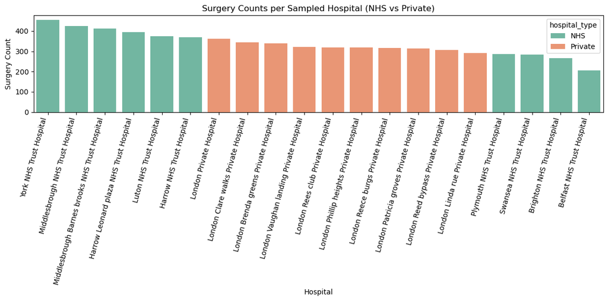

```python
import matplotlib.pyplot as plt
import seaborn as sns

sampledNhs["hospital_type"] = "NHS"
sampledPrivate["hospital_type"] = "Private"

# Combine both into one dataframe
df_sampled = pd.concat([sampledNhs, sampledPrivate], ignore_index=True)

# Sort by surgery count
df_sampled_sorted = df_sampled.sort_values("surgery_count", ascending=False)

# Plot
plt.figure(figsize=(12, 6))
sns.barplot(
    data=df_sampled_sorted,
    x="hospital_name",
    y="surgery_count",
    hue="hospital_type",
    dodge=False,
    palette="Set2"
)

plt.title("Surgery Counts per Sampled Hospital (NHS vs Private)")
plt.xticks(rotation=75, ha="right")
plt.ylabel("Surgery Count")
plt.xlabel("Hospital")
plt.tight_layout()
plt.show()
```

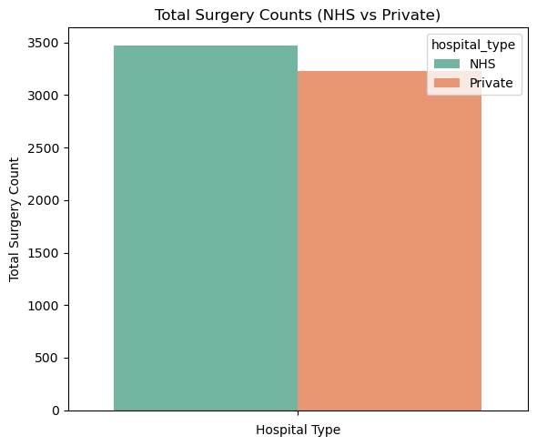

```python
# Total surgeries by type
totals = df_sampled.groupby("hospital_type")["surgery_count"].sum().reset_index()

# Plot
plt.figure(figsize=(6, 5))
sns.barplot(data=totals, hue="hospital_type", y="surgery_count", palette="Set2")

plt.title("Total Surgery Counts (NHS vs Private)")
plt.ylabel("Total Surgery Count")
plt.xlabel("Hospital Type")
plt.tight_layout()
plt.show()
```

Result of graphs: Shows good distribution from each hospital type, suitable to be tested on the Chi-Square test.

```python
dfSurgeryHospital.head()
```

|  | surgery_ID | patient_ID | hospital_ID | surgery_type | surgery_outcome | hospital_name |
| --- | --- | --- | --- | --- | --- | --- |
| 0 | SG001 | P327281 | H216 | Bladder Cancer Resection | Infection | Middlesbrough NHS Trust Hospital |
| 1 | SG002 | P277060 | H171 | Gastrectomy | Complications | Cardiff General Hospital |
| 2 | SG003 | P358930 | H004 | C-section | Recovered | London Private Hospital |
| 3 | SG004 | P90460 | H182 | Thyroidectomy | Partial Success | Brighton NHS Trust Hospital |
| 4 | SG005 | P292996 | H239 | Ureteral Stent Placement | Unsuccessful | Telford NHS Trust Hospital |

```python
dfnhs_priv = dfSurgeryHospital[dfSurgeryHospital['hospital_ID'].isin(selectedHospitalID)]
dfnhs_priv.head()
```

|  | surgery_ID | patient_ID | hospital_ID | surgery_type | surgery_outcome | hospital_name |
| --- | --- | --- | --- | --- | --- | --- |
| 0 | SG001 | P327281 | H216 | Bladder Cancer Resection | Infection | Middlesbrough NHS Trust Hospital |
| 2 | SG003 | P358930 | H004 | C-section | Recovered | London Private Hospital |
| 3 | SG004 | P90460 | H182 | Thyroidectomy | Partial Success | Brighton NHS Trust Hospital |
| 6 | SG007 | P123062 | H216 | Prostatectomy | Partial Success | Middlesbrough NHS Trust Hospital |
| 10 | SG011 | P81385 | H217 | Prostatectomy | Infection | Middlesbrough Barnes brooks NHS Trust Hospital |

```python
# Assume that successful surgery outcomes are defined by: Successful & Recovered
# Assume that unsuccessful surgery outcomes are defined by: Unsuccessful, Complications & Partial Success
dfnhs_priv = dfnhs_priv.copy()

# Define outcomes considered successful
success_outcomes = {"Successful", "Recovered"}

# Add a binary column for success: 1 = success, 0 = failure
dfnhs_priv["successful_outcome"] = dfnhs_priv["surgery_outcome"].isin(success_outcomes).astype(int)
dfnhs_priv.head()
```

|  | surgery_ID | patient_ID | hospital_ID | surgery_type | surgery_outcome | hospital_name | successful_outcome |
| --- | --- | --- | --- | --- | --- | --- | --- |
| 0 | SG001 | P327281 | H216 | Bladder Cancer Resection | Infection | Middlesbrough NHS Trust Hospital | 0 |
| 2 | SG003 | P358930 | H004 | C-section | Recovered | London Private Hospital | 1 |
| 3 | SG004 | P90460 | H182 | Thyroidectomy | Partial Success | Brighton NHS Trust Hospital | 0 |
| 6 | SG007 | P123062 | H216 | Prostatectomy | Partial Success | Middlesbrough NHS Trust Hospital | 0 |
| 10 | SG011 | P81385 | H217 | Prostatectomy | Infection | Middlesbrough Barnes brooks NHS Trust Hospital | 0 |

```python
dfnhs_priv["hospital_type"] = dfnhs_priv["hospital_name"].apply(
    lambda x: "NHS" if "NHS" in x else "Private"
)
dfnhs_priv.head()
```

|  | surgery_ID | patient_ID | hospital_ID | surgery_type | surgery_outcome | hospital_name | successful_outcome | hospital_type |
| --- | --- | --- | --- | --- | --- | --- | --- | --- |
| 0 | SG001 | P327281 | H216 | Bladder Cancer Resection | Infection | Middlesbrough NHS Trust Hospital | 0 | NHS |
| 2 | SG003 | P358930 | H004 | C-section | Recovered | London Private Hospital | 1 | Private |
| 3 | SG004 | P90460 | H182 | Thyroidectomy | Partial Success | Brighton NHS Trust Hospital | 0 | NHS |
| 6 | SG007 | P123062 | H216 | Prostatectomy | Partial Success | Middlesbrough NHS Trust Hospital | 0 | NHS |
| 10 | SG011 | P81385 | H217 | Prostatectomy | Infection | Middlesbrough Barnes brooks NHS Trust Hospital | 0 | NHS |

```python
# Create contigency table
contingency_table = pd.crosstab(
    dfnhs_priv["hospital_type"],
    dfnhs_priv["successful_outcome"]
)

contingency_table
```

| successful_outcome hospital_type | 0 | 1 |
| --- | --- | --- |
| NHS | 2363 | 1105 |
| Private | 2175 | 1053 |

Perform Chi-Square Test

```python
from scipy.stats import chi2_contingency

# Perform the chi-square test
chi2_stat, p_value, dof, expected = chi2_contingency(contingency_table)

print(f"Chi-Square Statistic: {chi2_stat:.4f}")
print(f"p-value: {p_value:.4f}")
print(f"Degrees of Freedom: {dof}")
print("Expected Frequencies:")
print(expected)

# Check if the expected frequencies are valid
print("\nMinimum Expected Frequency:", expected.min())
```

```
Chi-Square Statistic: 0.4059
p-value: 0.5241
Degrees of Freedom: 1
Expected Frequencies:
[[2350.32616487 1117.67383513]
 [2187.67383513 1040.32616487]]

Minimum Expected Frequency: 1040.326164874552
```

**Results:** These results indicate that the difference in successful surgery outcomes between NHS Hospitals and Private Hospitals is not statistically significant as the p value is greater than 0.05 (0.52> 0.05). This suggests that the type of hospital (private vs NHS) does not significantly impact the likelihood of successful surgery outcomes, and so NHS hospitals are just as effective as private hospitals.

The test satisfies a key assumption of the Chi-Square Test where the minimum expected frequency in each cell is well above 5 (minimum expected frequency = 1040), ensuring the chi-square approximation is reliable. Thus, the conclusion drawn from this test is likely to be accurate.

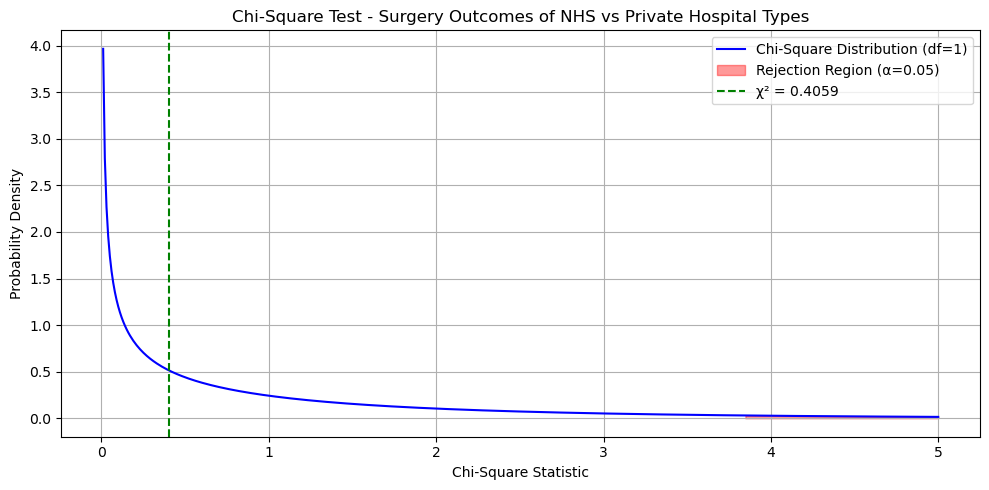

```python
# Visualizing the Chi-Square distribution curve
from scipy.stats import chi2

#Significance level
alpha = 0.05

# Define range of x values
x = np.linspace(0, 5, 500)
y = chi2.pdf(x, df=dof)

critical_value = chi2.ppf(1 - alpha, df=dof)

plt.figure(figsize=(10, 5))
plt.plot(x, y, label='Chi-Square Distribution (df=1)', color='blue')

# Shade the critical region (rejection region)
plt.fill_between(x, y, where=(x >= critical_value), color='red', alpha=0.4, label='Rejection Region (α=0.05)')

# Plot test statistic
plt.axvline(chi2_stat, color='green', linestyle='--', label=f'χ² = {chi2_stat:.4f}')

plt.title('Chi-Square Test - Surgery Outcomes of NHS vs Private Hospital Types')
plt.xlabel('Chi-Square Statistic')
plt.ylabel('Probability Density')
plt.legend()
plt.grid(True)
plt.tight_layout()
plt.show()
```

**Limitation:**

- The binary classification of success and failure may oversimplify the range of possible surgical outcomes.
- The findings may not be representative of all NHS and private hospitals, as this analysis only includes 20 hospitals across the UK.T he analysis also does not consider patient demographics, surgery complexity and surgeon experience which may also influence outcomes.

## Solution 3: Unsupervised Learning K-means Clustering

**Problem:** One potential application the NHS is exploring is identifying high-risk patients who may require more intensive monitoring. By recognising these patients early, the NHS can improve overall patient care and optimise resource allocation by prioritising those with greater needs. This also helps healthcare professionals avoid missing critical early intervention opportunities.

**Solution:** To address this, I used an unsupervised machine learning approach via K-Means clustering to segment patients based on their hospital visit patterns and clinical indicators.

The model uses features such as:

- Number of total visits: High number of visits are more likely to have chronic conditions
- Rate of hospital visits within 30 days : Frequent revisits within a month may indicate instability in a patient’s condition
- Age: Older patients generally have higher risk to chronic illnesses
- Average days since last hospital visit: Shorter intervals between visits may signal active treatment cycles or poor health management
- Frequency of visits according to the visit type: Different visit types represent different levels of care intensity.
- Presence of chronic conditions: Flags patients with long-term health risks.

**Justification:** Identifying high-risk patients which lack predefined labels makes this well-suited for an unsupervised learning approach. Instead of predicting a known risk score, the goal is to discover natural groupings in patient behaviour and clinical patterns that may indicate varying levels of risk which can be done by K-means clustering. It is also easy to interpret allowing stakeholders to understand characteristics of each cluster (high-risk vs low-risk patients).

Step 1: Extracting the features for the K-means model

I will be working on the dfVisit dataframe from the 1st supervised learning model as it already includes certain features that will useful for the k-means model. For reference again, the dfVisit model is shown below:

```python
dfVisit.head()
```

|  | patient_ID | visit_ID | visit_results | visit_date | visit_type | revisited_within_30_days | patient_gender | age_at_visit | diagnosis | num_previous_visits | days_since_last_visit | chronic_flag |
| --- | --- | --- | --- | --- | --- | --- | --- | --- | --- | --- | --- | --- |
| 0 | P001 | AP001 | None | 2024-04-09 | appointment | 0 | F | 85 | tension headache | 0 | -1.0 | 0 |
| 1 | P001 | SG43872 | Partial Success | 2025-01-31 | surgery | 0 | F | 86 | hysterectomy | 1 | 297.0 | 0 |
| 2 | P002 | AP002 | None | 2024-07-30 | appointment | 0 | F | 57 | routine health checkup | 0 | -1.0 | 0 |
| 3 | P003 | AP003 | None | 2024-09-18 | appointment | 0 | M | 50 | routine health checkup | 0 | -1.0 | 0 |
| 4 | P005 | AP005 | None | 2024-02-27 | appointment | 0 | M | 20 | gastric discomfort | 0 | -1.0 | 0 |

- The issue in this dataframe (dfVisit) is that there are multiple rows with the same patient (as the same patient can have mulitple records)
- For this model, I will be creating a new model, dfRiskProfile which has records of each unique patient.

```python
# Calculate the average number of times that the patient have revisited the hospital within 30 days
dfRiskProfile = dfVisit.groupby("patient_ID")["revisited_within_30_days"].mean().reset_index()
dfRiskProfile.columns = ["patient_ID", "mean_revisited_within_30_days"]

dfRiskProfile.head()
```

|  | patient_ID | mean_revisited_within_30_days |
| --- | --- | --- |
| 0 | P001 | 0.0 |
| 1 | P002 | 0.0 |
| 2 | P003 | 0.0 |
| 3 | P005 | 0.0 |
| 4 | P006 | 0.0 |

```python
# Calculate the number of total visits a patient has had
dfNumVisits = dfVisit.groupby("patient_ID")["visit_ID"].count().reset_index()
dfNumVisits.columns = ["patient_ID", "num_total_visits"]

# Add num_total_visits into dfRiskProfile
if 'num_total_visits' not in dfRiskProfile.columns:
    dfRiskProfile = dfRiskProfile.merge(dfNumVisits, on="patient_ID", how="left")

dfRiskProfile.head()
```

|  | patient_ID | mean_revisited_within_30_days | num_total_visits |
| --- | --- | --- | --- |
| 0 | P001 | 0.0 | 2 |
| 1 | P002 | 0.0 | 1 |
| 2 | P003 | 0.0 | 1 |
| 3 | P005 | 0.0 | 1 |
| 4 | P006 | 0.0 | 1 |

```python
# Calculate mean age from dfVisit
# In dfVisit, patients may have multiple records with different ages at visit depending on date of visit, so we need to make this uniform

dfMeanAge = dfVisit.groupby("patient_ID")["age_at_visit"].mean().reset_index()
dfMeanAge.columns = ["patient_ID", "mean_age_at_visit"]

# Add mean_age_at_visit to dfRiskProfile
if 'mean_age_at_visit' not in dfRiskProfile.columns:
    dfRiskProfile = dfRiskProfile.merge(dfMeanAge, on="patient_ID", how="left")

dfRiskProfile.head()
```

|  | patient_ID | mean_revisited_within_30_days | num_total_visits | mean_age_at_visit |
| --- | --- | --- | --- | --- |
| 0 | P001 | 0.0 | 2 | 85.5 |
| 1 | P002 | 0.0 | 1 | 57.0 |
| 2 | P003 | 0.0 | 1 | 50.0 |
| 3 | P005 | 0.0 | 1 | 20.0 |
| 4 | P006 | 0.0 | 1 | 60.0 |

```python
# Calculate average days since last visit
dfMeanGap = dfVisit.groupby("patient_ID")["days_since_last_visit"].mean().reset_index()
dfMeanGap.columns = ["patient_ID", "mean_days_since_last_visit"]

# Add mean_days_since_last_visit to dfRiskProfile
if 'mean_days_since_last_visit' not in dfRiskProfile.columns:
    dfRiskProfile = dfRiskProfile.merge(dfMeanGap, on="patient_ID", how="left")

dfRiskProfile.head()
```

|  | patient_ID | mean_revisited_within_30_days | num_total_visits | mean_age_at_visit | mean_days_since_last_visit |
| --- | --- | --- | --- | --- | --- |
| 0 | P001 | 0.0 | 2 | 85.5 | 148.0 |
| 1 | P002 | 0.0 | 1 | 57.0 | -1.0 |
| 2 | P003 | 0.0 | 1 | 50.0 | -1.0 |
| 3 | P005 | 0.0 | 1 | 20.0 | -1.0 |
| 4 | P006 | 0.0 | 1 | 60.0 | -1.0 |

```python
# Use one hot encoding to get the frequency of each visit type (surgery/appointment/test) from patients' history of visits

dfVisitCopy = dfVisit.copy()

dfVisitCopy = pd.get_dummies(dfVisitCopy, columns=["visit_type"], prefix="visit_type")
dfVisitTypeCount = dfVisitCopy.groupby("patient_ID")[["visit_type_appointment", "visit_type_surgery", "visit_type_test"]].sum().reset_index()

dfVisitTypeCount.head()
```

|  | patient_ID | visit_type_appointment | visit_type_surgery | visit_type_test |
| --- | --- | --- | --- | --- |
| 0 | P001 | 1 | 1 | 0 |
| 1 | P002 | 1 | 0 | 0 |
| 2 | P003 | 1 | 0 | 0 |
| 3 | P005 | 1 | 0 | 0 |
| 4 | P006 | 1 | 0 | 0 |

```python
# Merge visit type counts into dfRiskProfile
if ("visit_type_surgery" not in dfRiskProfile.columns and "visit_type_appointment" not in dfRiskProfile.columns and "visit_type_test" not in dfRiskProfile.columns):
    dfRiskProfile = dfRiskProfile.merge(dfVisitTypeCount, on="patient_ID", how="left")

dfRiskProfile.head()
```

|  | patient_ID | mean_revisited_within_30_days | num_total_visits | mean_age_at_visit | mean_days_since_last_visit | visit_type_appointment | visit_type_surgery | visit_type_test |
| --- | --- | --- | --- | --- | --- | --- | --- | --- |
| 0 | P001 | 0.0 | 2 | 85.5 | 148.0 | 1 | 1 | 0 |
| 1 | P002 | 0.0 | 1 | 57.0 | -1.0 | 1 | 0 | 0 |
| 2 | P003 | 0.0 | 1 | 50.0 | -1.0 | 1 | 0 | 0 |
| 3 | P005 | 0.0 | 1 | 20.0 | -1.0 | 1 | 0 | 0 |
| 4 | P006 | 0.0 | 1 | 60.0 | -1.0 | 1 | 0 | 0 |

```python
# Add chronic_flag from dfChronicPatient (created in patient readmission model 1) into dfRiskProfile
if 'chronic_flag' not in dfRiskProfile.columns:
    dfRiskProfile = dfRiskProfile.merge(dfChronicPatient, on="patient_ID", how="left")

dfRiskProfile.head()
```

|  | patient_ID | mean_revisited_within_30_days | num_total_visits | mean_age_at_visit | mean_days_since_last_visit | visit_type_appointment | visit_type_surgery | visit_type_test | chronic_flag |
| --- | --- | --- | --- | --- | --- | --- | --- | --- | --- |
| 0 | P001 | 0.0 | 2 | 85.5 | 148.0 | 1 | 1 | 0 | 0 |
| 1 | P002 | 0.0 | 1 | 57.0 | -1.0 | 1 | 0 | 0 | 0 |
| 2 | P003 | 0.0 | 1 | 50.0 | -1.0 | 1 | 0 | 0 | 0 |
| 3 | P005 | 0.0 | 1 | 20.0 | -1.0 | 1 | 0 | 0 | 0 |
| 4 | P006 | 0.0 | 1 | 60.0 | -1.0 | 1 | 0 | 0 | 0 |

At the point, the dataframe contains all features to identify high risk patients, ready for the unsupervised learning model .

**Step 2:** Scale features to ensure fair contribution to distance-based clustering.

```python
# Drop patient_ID for clustering
X = dfRiskProfile.drop("patient_ID", axis=1)

scaler = StandardScaler()
X_scaled = scaler.fit_transform(X)
```

**Step 3:** Apply k-Means clustering

```python
from sklearn.cluster import KMeans

kmeans = KMeans(n_clusters=3, random_state=42)
kmeans
```

```
KMeans(n_clusters=3, random_state=42)
```

```python
# Fit k means object to dataset and predict
clusters = kmeans.fit_predict(X_scaled)

# Add cluster in dfRiskProfile
if 'cluster' not in dfRiskProfile.columns:
    dfRiskProfile["cluster"] = clusters
dfRiskProfile.head()
```

|  | patient_ID | mean_revisited_within_30_days | num_total_visits | mean_age_at_visit | mean_days_since_last_visit | visit_type_appointment | visit_type_surgery | visit_type_test | chronic_flag | cluster |
| --- | --- | --- | --- | --- | --- | --- | --- | --- | --- | --- |
| 0 | P001 | 0.0 | 2 | 85.5 | 148.0 | 1 | 1 | 0 | 0 | 1 |
| 1 | P002 | 0.0 | 1 | 57.0 | -1.0 | 1 | 0 | 0 | 0 | 0 |
| 2 | P003 | 0.0 | 1 | 50.0 | -1.0 | 1 | 0 | 0 | 0 | 0 |
| 3 | P005 | 0.0 | 1 | 20.0 | -1.0 | 1 | 0 | 0 | 0 | 0 |
| 4 | P006 | 0.0 | 1 | 60.0 | -1.0 | 1 | 0 | 0 | 0 | 0 |

Visuals of the 3 clusters:

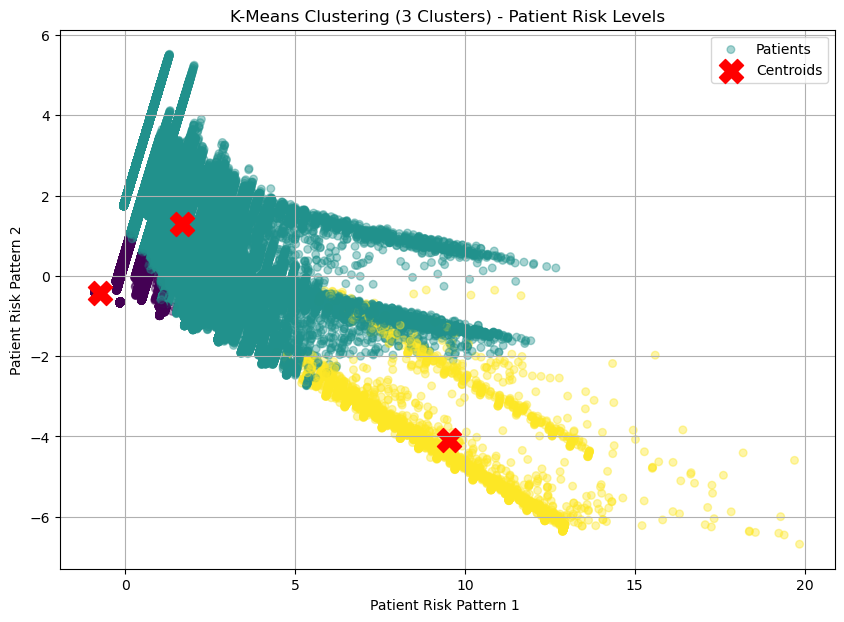

```python
from sklearn.decomposition import PCA

# Reduce dimensionality for plotting
pca = PCA(n_components=2)
X_pca = pca.fit_transform(X_scaled)

# Transform the cluster centroids into PCA space
centroids_pca = pca.transform(kmeans.cluster_centers_)

# Plot
plt.figure(figsize=(10, 7))
plt.scatter(X_pca[:, 0], X_pca[:, 1], c=dfRiskProfile["cluster"], cmap='viridis', s=30, edgecolor=None, alpha=0.4, label='Patients')
plt.scatter(centroids_pca[:, 0], centroids_pca[:, 1], c='red', marker='X', s=300, label='Centroids')

plt.title("K-Means Clustering (3 Clusters) - Patient Risk Levels")
plt.xlabel("Patient Risk Pattern 1 ")
plt.ylabel("Patient Risk Pattern 2")
plt.legend()
plt.grid(True)
plt.show()
```

```python
# Investigate the mean of each feature in the 3 clusters

dfRiskProfile.groupby("cluster").mean(numeric_only=True)
```

| cluster | mean_revisited_within_30_days | num_total_visits | mean_age_at_visit | mean_days_since_last_visit | visit_type_appointment | visit_type_surgery | visit_type_test | chronic_flag |
| --- | --- | --- | --- | --- | --- | --- | --- | --- |
| 0 | 0.003278 | 1.043235 | 53.456122 | 0.347058 | 1.020571 | 0.000000 | 0.022664 | 0.142141 |
| 1 | 0.204654 | 3.369502 | 53.698320 | 55.301915 | 2.286624 | 0.562061 | 0.520816 | 0.386226 |
| 2 | 0.784182 | 15.263278 | 53.386797 | 14.711660 | 1.631476 | 0.134897 | 13.496905 | 0.988921 |

**Results:**

Cluster 0: Low risk patients

- Low number of hospital visits (averages at 1) and very rarely revisits
- Almost no tests or surgeries (mostly appointments, no surgery visit type)
- Only about 14% of patients has had a history of chronic diseases

Cluster 1: Moderate risk patients

- Moderate number of hospital visits (averages at 3) and at and average will revisit in 55 days (about 2 months gap)
- Has record of having a mix of appointment, surgery and test visit types but at low frequencies (Averages at 2 appointment visits, and 0 or 1 appointment/test visits)
- About 38% of patients has had a history of chronic diseases

Cluster 2: High risk patients

- Frequent hospital visits (15+)
- Very high revisit within 30 days rate (78%)
- Has had high number of tests (13+), over surgeries and appointments
- Almost all patients have chronic diseases (99%)

Thus, this enables the NHS to prioritize patients that fall in cluster 2 for more intensive monitoring and proactive care, potentially to improve patient outcomes. Patients in cluster 1 may also benefit from targeted management for early intervention to prevent future complications or readmissions.

**Limitations:**

Chronic flag labels were based on assumption from a small set of lists provided by the NHS website rather than true clinical records that were not provided in given data, thus may misclassify certain conditions. Additionally, the model assumes patients with similar metrics share similar risk profiles, which may not capture rare or outlier cases.

## Task 4: Ethics and Analysis (10 Marks)

**I.** (**5 marks**) Discuss the ethical implications of your modelling solutions given in Task 3. How can these ethical challenges be mitigated in a real-world NHS setting? Your answer to this question must not exceed **200 words**.

Across all three models, 2 ethical principles most at risk involve fairness and accountability. In the patient readmission prediction model and the clustering of high risk patients model, relying on features like chronic condition flag may unfairly disadvantage patients with pre-existing conditions by disproportionately flagging them as high risk. These models risk misclassifying patients as high-risk based on incomplete or assumed data, potentially overlooking other at-risk individuals who may also be likely to be readmitted. The NHS vs private hospital comparison model risks stigmatizing NHS hospitals if it overlooks contextual factors such as patient complexity or surgeon experience, which differs in both hospitals, thus may produce unfair results when compared.

To mitigate these risks, models should be audited regularly for bias, particularly across protected groups, and developed in consultation with clinicians to ensure medically relevant and fair interpretations. Outputs should support and not replace clinical judgment, and any patient flagged by the model should be subject to professional review.

Moreover, since medical data falls under the “special category” in GDPR, it must be anonymised, securely stored, and used with informed consent. Even if data processing here is justified for vital or public interest, transparency remains essential.

**II.** (**5 marks**) Write a Python script **using SQL** to analyse the database from Task 2 and generate results showing: *(a)* The distribution of hospitals across cities. *(b)* For each hospital, its name, city, the number of departments, and the number of patients who prefer that hospital, using outer join. Sort the hospitals within each city by the number of preferred patients in descending order.

**Write your answer here (text cell(s) to be used, as appropriate)**

a) Distribution of hospitals across cities

```python
con = sqlite3.connect("DATA Assessment.db")

query = """
SELECT
  TRIM(SUBSTR(
    hospital_location,
    INSTR(hospital_location, ',') + 1,
    INSTR(SUBSTR(hospital_location, INSTR(hospital_location, ',') + 1), ',') - 1
  )) AS city,
  COUNT(*) AS hospital_count
FROM hospital
GROUP BY city;
"""

# Store the result in dataframe
df_result = pd.read_sql_query(query, con)

con.close()
df_result
```

|  | city | hospital_count |
| --- | --- | --- |
| 0 | Aberdeen | 2 |
| 1 | Ashford | 1 |
| 2 | Basingstoke | 1 |
| 3 | Belfast | 4 |
| 4 | Birmingham | 12 |
| 5 | Blackpool | 1 |
| 6 | Bradford | 6 |
| 7 | Brighton | 3 |
| 8 | Bristol | 5 |
| 9 | Cambridge | 1 |
| 10 | Cardiff | 4 |
| 11 | Cheltenham | 1 |
| 12 | Coventry | 4 |
| 13 | Derby | 3 |
| 14 | Dundee | 2 |
| 15 | Edinburgh | 6 |
| 16 | Exeter | 1 |
| 17 | Glasgow | 7 |
| 18 | Harrow | 2 |
| 19 | Hastings | 1 |
| 20 | Leeds | 8 |
| 21 | Leicester | 4 |
| 22 | Liverpool | 5 |
| 23 | London | 93 |
| 24 | Luton | 2 |
| 25 | Manchester | 6 |
| 26 | Middlesbrough | 2 |
| 27 | Milton Keynes | 2 |
| 28 | Newcastle | 15 |
| 29 | Norwich | 2 |
| 30 | Nottingham | 3 |
| 31 | Oxford | 2 |
| 32 | Plymouth | 3 |
| 33 | Preston | 1 |
| 34 | Reading | 2 |
| 35 | Redditch | 1 |
| 36 | Sheffield | 6 |
| 37 | Slough | 2 |
| 38 | Southampton | 3 |
| 39 | Southend-on-Sea | 2 |
| 40 | Stoke-on-Trent | 3 |
| 41 | Sunderland | 2 |
| 42 | Swansea | 3 |
| 43 | Swindon | 2 |
| 44 | Telford | 2 |
| 45 | Wakefield | 1 |
| 46 | Woking | 1 |
| 47 | Wokingham | 2 |
| 48 | Wolverhampton | 3 |
| 49 | York | 2 |

b) For each hospital, its name, city, the number of departments, and the number of patients who prefer that hospital, using outer join. Sort the hospitals within each city by the number of preferred patients in descending order.

```python
con = sqlite3.connect("DATA Assessment.db")

query = """
WITH hospital_city AS (
    SELECT
        hospital_ID,
        hospital_name,
        TRIM(SUBSTR(
            hospital_location,
            INSTR(hospital_location, ',') + 1,
            INSTR(SUBSTR(hospital_location, INSTR(hospital_location, ',') + 1), ',') - 1
        )) AS city
    FROM hospital
),

department_count AS (
    SELECT
        hospital_ID,
        COUNT(*) AS department_sum
    FROM department
    GROUP BY hospital_ID
),

patient_preferred_hospital_count AS (
    SELECT
        patient_preferred_hospital_ID AS hospital_ID,
        COUNT(*) AS num_preferred_patients
    FROM patient
    GROUP BY patient_preferred_hospital_ID
)

SELECT
    h.hospital_name,
    h.city,
    d.department_sum,
    p.num_preferred_patients
FROM hospital_city h
LEFT JOIN department_count d ON h.hospital_ID = d.hospital_ID
LEFT JOIN patient_preferred_hospital_count p ON h.hospital_ID = p.hospital_ID
ORDER BY h.city, p.num_preferred_patients DESC;
"""

df_result = pd.read_sql_query(query, con)

con.close()

df_result
```

|  | hospital_name | city | department_sum | num_preferred_patients |
| --- | --- | --- | --- | --- |
| 0 | Aberdeen NHS Trust Hospital | Aberdeen | 14 | 3183 |
| 1 | Aberdeen General Hospital | Aberdeen | 14 | 3146 |
| 2 | Ashford NHS Trust Hospital | Ashford | 14 | 6333 |
| 3 | Basingstoke General Hospital | Basingstoke | 14 | 6378 |
| 4 | Belfast NHS Trust Hospital | Belfast | 14 | 1665 |
| ... | ... | ... | ... | ... |
| 247 | Wolverhampton Community Hospital | Wolverhampton | 7 | 2139 |
| 248 | Wolverhampton West ford NHS Trust Hospital | Wolverhampton | 14 | 2103 |
| 249 | Wolverhampton NHS Trust Hospital | Wolverhampton | 14 | 2095 |
| 250 | York General Hospital | York | 14 | 3264 |
| 251 | York NHS Trust Hospital | York | 14 | 3200 |

252 rows × 4 columns

## Overall Academic Quality (10 Marks)

10 marks are allocated for the clarity and cohesiveness of your answers (both text and code) across all tasks with appropriate, relevant and effective analysis and presentation of the results.

## Deliverables

You should submit the following to the submission point on VLE Ultra:

1. the SQLite database produced in Task 2;
2. the completed Jupyter notebook (both .ipynb and HTML files) containing solutions for all the tasks. A template has been provided on VLE;
3. any figures or diagrams that are included in your answers in the Jupyter notebook.

For each task where text is required, we have provided guidelines above on the suggested word counts. Exceeding the word count will result in any work beyond the word count being disregarded when assessing.